# Homework 3

wendyxwang

Tuesday, February 24, 2015

# Homework 3 Questions:

Reproduce the results presented in Figure 2 of the following paper: Qian, F., Bolen, C. R., Jing, C., Wang, X., Zheng, W., Zhao, H., et al. (2013). Impaired toll-like receptor 3-mediated immune responses from macrophages of patients chronically infected with hepatitis C virus. Clinical and Vaccine Immunology : CVI, 20(2), 146–155. doi:10.1128/CVI.00530-12

You will have to:

Get the data from GEO Normalize the data (if necessary) Use limma to test for differential expression Display the results using a heatmap [Hint: Use the pheatmap package]

# Answers:

First, set up some general options and get the packages ready

```r
library("knitr")
opts_chunk$set(tidy=TRUE, tidy.opts=list(blank=FALSE, width.cutoff=60), cache=TRUE, messages=FALSE)

library(limma)
library(Biobase)
library(data.table)
library(statmod)

#set working directory
setwd("E:/Course2015Winter/BIOST578/RStudio clone/HW3_Xiaoliang_Wang")
```

# 1. Get data from GEO

```r
library(GEOquery)
# Get the data that was used in the paper
GSE40812_set <- getGEO("GSE40812", destdir = "Data/GEO/")[[1]]
```

```
## ftp://ftp.ncbi.nlm.nih.gov/geo/series/GSE40nnn/GSE40812/matrix/
## Found 1 file(s)
## GSE40812_series_matrix.txt.gz
## Using locally cached version: Data/GEO//GSE40812_series_matrix.txt.gz
## Using locally cached version of GPL10558 found here:
## Data/GEO//GPL10558.soft
```

```r
# somehow my code was using the soft file, so I need to force
# it to use the matrix.gz file
# check out the eSet
str(GSE40812_set, max.level = 2)
```

```
## Formal class 'ExpressionSet' [package "Biobase"] with 7 slots
##   ..@ experimentData   :Formal class 'MIAME' [package "Biobase"] with 13 slots
##   ..@ assayData        :<environment: 0x0f73bdc4>
##   ..@ phenoData        :Formal class 'AnnotatedDataFrame' [package "Biobase"] with 4 slots
##   ..@ featureData      :Formal class 'AnnotatedDataFrame' [package "Biobase"] with 4 slots
##   ..@ annotation       : chr "GPL10558"
##   ..@ protocolData     :Formal class 'AnnotatedDataFrame' [package "Biobase"] with 4 slots
##   ..@ .__classVersion__:Formal class 'Versions' [package "Biobase"] with 1 slots
```

```r
class(GSE40812_set)
```

```
## [1] "ExpressionSet"
## attr(,"package")
## [1] "Biobase"
```

```r
exprs(GSE40812_set)[1:3, 1:4]
```

```
##              GSM1002366 GSM1002367 GSM1002368 GSM1002369
## ILMN_1343291  13.927980  13.982486  13.842999  13.828501
## ILMN_1343295  11.604746  11.562698  11.907338  11.897587
## ILMN_1651199   6.554031   6.435446   6.426153   6.517762
```

```r
pData(GSE40812_set)[1:2, ]
```

[output not shown]

Clean the pData

```r
gset <- GSE40812_set
# Sanitize data
sanitize_pdata <- function(pd) {
    keepCols <- c("title", "geo_accession", "source_name_ch1",
        "characteristics_ch1", "characteristics_ch1.2")
    pd <- pd[, keepCols]
    colnames(pd) <- c("ptid", "GSM_id", "source", "infection_status",
        "treatment")
    # we need to substract the id from title for paired
    # comparison later
    pd$ptid <- sapply(strsplit(as.character(pd$ptid), "_"), function(x) x[[2]])
    pd$infection_status <- gsub(".*: ", "", pd$infection_status)
    pd$treatment <- gsub(".*: ", "", pd$treatment)
    pd
}
pData(gset) <- sanitize_pdata(pData(gset))
pData(gset)[1:10, ]
```

```
##            ptid     GSM_id                      source infection_status
## GSM1002366 2046 GSM1002366 Monocyte-derived Macrophage              Neg
## GSM1002367 2046 GSM1002367 Monocyte-derived Macrophage              Neg
## GSM1002368 3049 GSM1002368 Monocyte-derived Macrophage              Pos
## GSM1002369 3050 GSM1002369 Monocyte-derived Macrophage              Pos
## GSM1002370 3049 GSM1002370 Monocyte-derived Macrophage              Pos
## GSM1002371 3050 GSM1002371 Monocyte-derived Macrophage              Pos
## GSM1002372 2048 GSM1002372 Monocyte-derived Macrophage              Neg
## GSM1002373 2048 GSM1002373 Monocyte-derived Macrophage              Neg
## GSM1002374 2049 GSM1002374 Monocyte-derived Macrophage              Neg
## GSM1002375 3052 GSM1002375 Monocyte-derived Macrophage              Pos
##            treatment
## GSM1002366      Mock
## GSM1002367 Poly IC H
## GSM1002368      Mock
## GSM1002369      Mock
## GSM1002370 Poly IC H
## GSM1002371 Poly IC H
## GSM1002372      Mock
## GSM1002373 Poly IC H
## GSM1002374      Mock
## GSM1002375      Mock
```

We also want to make sure we are only using the Macrophage data

```r
gset_m <- gset
macrophage <- pData(gset_m)[pData(gset_m)$source == "Monocyte-derived Macrophage",
    ]
eset <- gset_m[, rownames(macrophage)]
```

Some of the data has been excluded.

# 2. Normalize the data if necessary

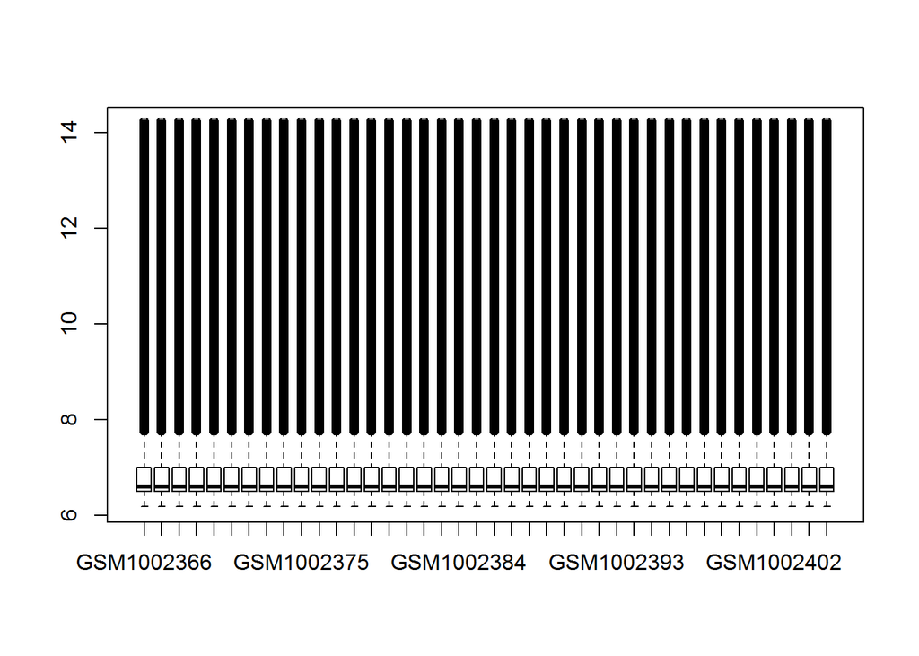

```r
## From the viewer, it seems like the data has already been
## normalized. make a boxplot
boxplot(exprs(eset))
```

```r
# seems really comparable So, we do not need to normalize the
# data
```

# 3. Use limma to test for differential expression

```r
# design matrix
mm <- model.matrix(~treatment, data = eset)
# lmfit
fit <- lmFit(eset, mm)
ebay <- eBayes(fit)
```

Test for the treatment effect

```r
colnames(fit$coef)
```

```
## [1] "(Intercept)"        "treatmentPoly IC H"
```

```r
# We have mock as reference treatment, and poly I:C(H) as the
# other treatment group
```

**Poly I:C(HMW) vs. MOCK**

```r
topPoly_H <- topTable(ebay, coef = "treatmentPoly IC H", number = Inf,
    sort.by = "none")
colnames(topPoly_H)
```

```
##  [1] "ID"                    "Species"
##  [3] "Source"                "Search_Key"
##  [5] "Transcript"            "ILMN_Gene"
##  [7] "Source_Reference_ID"   "RefSeq_ID"
##  [9] "Unigene_ID"            "Entrez_Gene_ID"
## [11] "GI"                    "Accession"
## [13] "Symbol"                "Protein_Product"
## [15] "Probe_Id"              "Array_Address_Id"
## [17] "Probe_Type"            "Probe_Start"
## [19] "SEQUENCE"              "Chromosome"
## [21] "Probe_Chr_Orientation" "Probe_Coordinates"
## [23] "Cytoband"              "Definition"
## [25] "Ontology_Component"    "Ontology_Process"
## [27] "Ontology_Function"     "Synonyms"
## [29] "Obsolete_Probe_Id"     "GB_ACC"
## [31] "logFC"                 "AveExpr"
## [33] "t"                     "P.Value"
## [35] "adj.P.Val"             "B"
```

```r
# Accoridng to the paper, use the cutoff values of 1.5 fold
# change and 0.05 FDR
summ_topPoly_H <- sum(topPoly_H$adj.P.Val < 0.05 & abs(topPoly_H$logFC) >=
    log2(1.5))
```

This returns 1146 significant results at the threshold that we selected.

```r
summ_topPoly_H_pos <- sum(topPoly_H$adj.P.Val < 0.05 & topPoly_H$logFC >=
    log2(1.5))
```

753 upregulated responses, and 393 downregulated reponses, which is the same as reported in the original paper.

**We then limit our analysis on the responsive genes**

```r
eset_r <- eset[topPoly_H$adj.P.Val < 0.05 & abs(topPoly_H$logFC) >
    log2(1.5), ]
pData(eset_r)$treatment <- ifelse(eset_r$treatment == "Mock",
    "Mock", "Poly")
infect_treat <- factor(paste(eset_r$infection_status, eset_r$treatment,
    sep = ""))
# re-define design matrix
mm_r <- model.matrix(~0 + infect_treat, data = eset_r)
colnames(mm_r) <- levels(infect_treat)
corfit <- duplicateCorrelation(eset_r, mm_r, block = pData(eset_r)$ptid)
corfit$consensus
```

```
## [1] 0.2883114
```

```r
fit_r <- lmFit(eset_r, mm_r, block = pData(eset_r)$ptid, correlation = corfit$consensus)
ebay_r <- eBayes(fit_r)
colnames(fit_r)
```

```
## [1] "NegMock" "NegPoly" "PosMock" "PosPoly"
```

We also need to definte contrast manually

```r
# specify contrast
cm <- makeContrasts(PolyMockforPos = PosPoly - PosMock, PolyMockforNeg = NegPoly -
    NegMock, PolyforPosNeg = PosPoly - NegPoly, MockforPosNeg = PosMock -
    NegMock, All = (PosPoly - PosMock) - (NegPoly - NegMock),
    levels = mm_r)
# Re-fit the model with specified contrast
fit_r2 <- contrasts.fit(fit_r, cm)
ebay_r2 <- eBayes(fit_r2)
```

**Check the significant genes**

```r
top_r <- topTable(ebay_r2, coef = "All", number = Inf, sort.by = "none",
    adjust.method = "BH")
summ_top_adj <- sum(top_r$adj.P.Val < 0.1)
# no genes were found to be significantly different following
# FDR corrections
summ_top_r <- sum(top_r$P.Val < 0.1)
# we have 41 probe sets returned.
```

Not sure why we have 2 probe sets fewer than reported in the paper

# 4. Display the results using a heatmap

```r
library(pheatmap)
# Subset the probes with significant difference in the second
# analysis
sign <- eset_r[top_r$P.Val < 0.1, ]
```

Draw heatmap

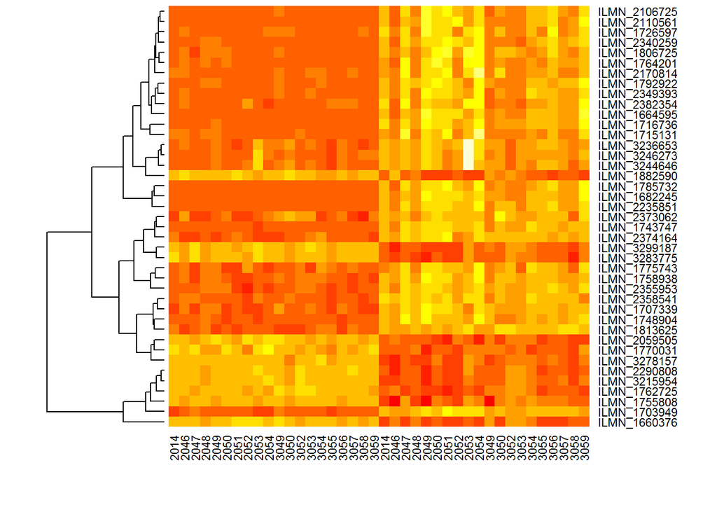

```r
sign_pd <- pData(sign)
sign_pd <- sign_pd[order(sign_pd$treatment, sign_pd$infection_status,
    sign_pd$ptid), ]
hm_colorder <- rownames(sign_pd)
hm_colnames <- sign_pd$ptid
hm_data <- exprs(sign)
hm_dt <- as.data.table(hm_data)
rownames(hm_dt) <- rownames(hm_data)
setcolorder(hm_dt, hm_colorder)
hm_data <- data.matrix(hm_dt)
colnames(hm_data) <- hm_colnames
heatmap(hm_data, Colv = NA)
```

## Citation

1. Dr. Gottardo BIOST 578A Differential Expression slides
2. LIMMA userguide